# Compare resource change metrics

August, 2024

## Measuring long-term gradual change and short-term shocks

Data sample for agriculture maize crop yield for the CROVER crop model, GFDL-ESM4, SSP 585, and for the United States. We compare the three main metrics computed:

1. End of the century (2070-2099) long-term % difference average compared to a fixed threshold of 5, 10, or 25% (code with gradual purple shades)
2. End of century (2070-2099) long-term % difference average compared to the 10th percentile limit from the historical period (1985-2015), which is used as a specific threshold per simulation
3. Years with shocks from 2SD of residuals from a smooth loess fit with span of 0.25, 0.5 or 0.75 (yellow, orange, and red fitted lines, respectively). The years and time-series points identified as experiencing a resource shock are colored in yellow, orange, or red.

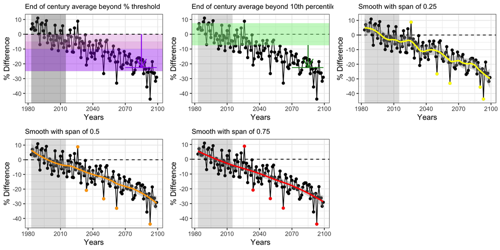

## How often are 10th percentile limits reached per sector?

To understand the effect of using the 10th percentile of the historic period, we look at the 10th percentile and the % difference by the end of the century. This plot is excluding outliers when the % difference is higher than 200 etc.

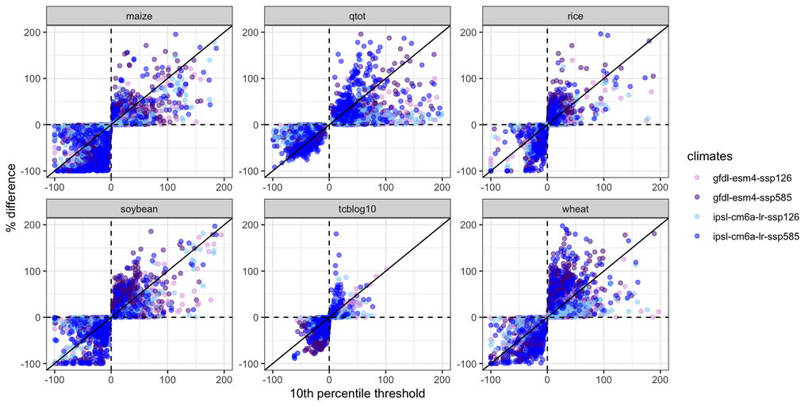

## Cross-sector aggregated metrics

To quantify the cross-sector change, we calculated:

1. The probability that at least 1, 2, or 3 resources change (sub-panels on the plot) beyond the 5, 10, or 25% fixed threshold per country and climate conditions (coded as 5, 10, and 25 on the x-axis)
2. The probability that at least 1, 2, or 3 resources change beyond the 10th percentile of the historical period per country and climate conditions (coded as pct on the x-axis)
3. The probability that there are at least one year from 2070-2099 during which at least 1, 2, or 3 resource shocks per country and climate conditions (coded as shock on the x-axis)

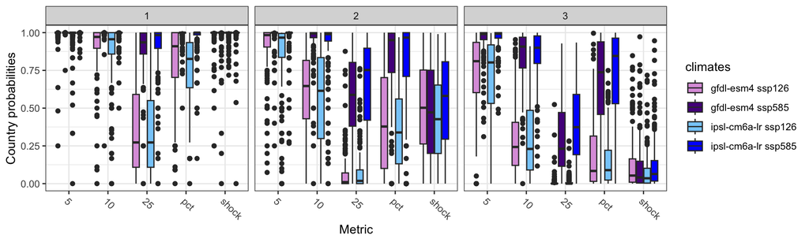

The plots below detail the correlation and relationships between the probability of at least two shock, the probability of at least 2 resources changing beyond 25% and the probability of at least 2 resources changing beyond the 10th or 90th percentile by the end of century by climate model and experiment. The Blue line is a loess smoother.

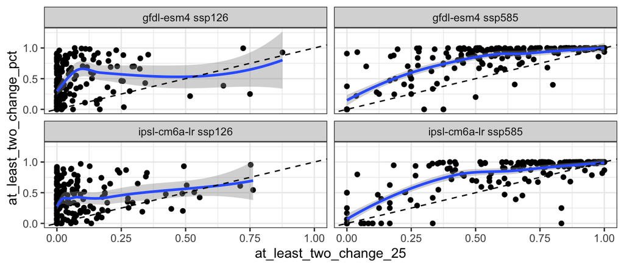

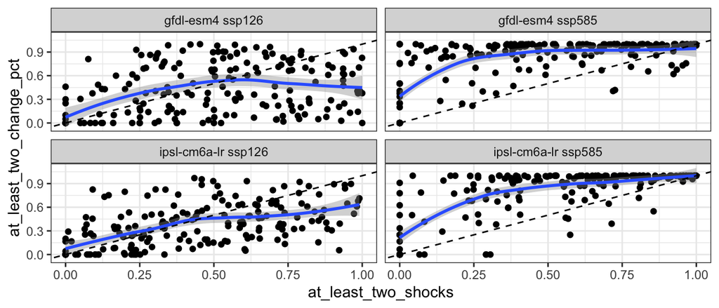

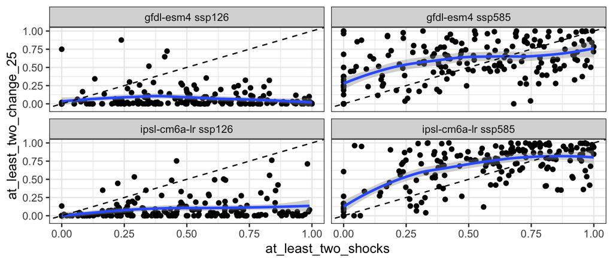